```python
%reload_ext autoreload
%autoreload 2
%matplotlib inline
```

# CNNs, CUDA and Hooks

> Training convolutional neural networks with CUDA and Pytorch hooks

```python
#export
from exp.nb_06 import *
```

```python
# import torch.nn.functional as F
# import torch.nn as nn
# import torch.optim as optim
```

## Get Data

```python
x_train,y_train,x_valid,y_valid = get_data()
```

```python
#export
def normalize_to(train, valid):
    m,s = train.mean(), train.std()
    return normalize(train, m, s), normalize(valid, m,s)
```

```python
x_train, x_valid = normalize_to(x_train, x_valid)
```

```python
train_ds,valid_ds = Dataset(x_train, y_train),Dataset(x_valid, y_valid)
nh,bs = 50,512
c = y_train.max().item()+1
loss_func = F.cross_entropy
```

```python
data = DataBunch(*get_dls(train_ds, valid_ds, bs), c)
```

```python
data.train_ds.x.mean(), data.train_ds.x.std()
```

```
(tensor(-6.2598e-06), tensor(1.))
```

## Basic CNN

We're going to implement a basic CNN using a some 2d conv layers.

### Lambda Class

If we want to make a func and put it into `nn.Sequential` it needs to be a `nn.Module`.

To do this we'll use a `Lambda` class that takes a function, inherits and initializes from `nn.Module` and then calls the function on the forward pass:

```python
#export
class Lambda(nn.Module):
    def __init__(self, func):
        super().__init__()
        self.func = func
    def forward(self, x):
        return self.func(x)
```

### Get CNN Model

First step is the use the `Lambda` class above to reshape our batches into shape:

BATCH x CHANNEL x HEIGHT x WIDTH

```python
#export
def flatten(x):
    return x.view(x.shape[0], -1)

def mnist_resize(x):
    return x.view(-1, 1, 28, 28)
```

```python
xb, yb = next(iter(data.train_dl))
xb.shape
```

```
torch.Size([512, 784])
```

```python
nb = mnist_resize(xb)
nb.shape
```

```
torch.Size([512, 1, 28, 28])
```

```python
def get_cnn_model(data):
    return nn.Sequential(
        Lambda(mnist_resize),
        nn.Conv2d( 1,  8, 5, padding=2, stride=2), nn.ReLU(), # stride 2 reduces image 14x14
        nn.Conv2d( 8, 16, 3, padding=1, stride=2), nn.ReLU(), # stride 2 reduces image 7x7
        nn.Conv2d(16, 32, 3, padding=1, stride=2), nn.ReLU(), # stride 2 reduces image 4x4
        nn.Conv2d(32, 32, 3, padding=1, stride=2), nn.ReLU(), # stride 2 reduces image 2x2
        nn.AdaptiveAvgPool2d(1),
        Lambda(flatten),
        nn.Linear(32, data.c)
    )
```

```python
model = get_cnn_model(data)
```

```python
opt = optim.SGD(model.parameters(), lr=0.4)
learn = Learner(model, opt, loss_func, data)
run = Runner(cb_funcs = [Recorder, partial(AvgStatsCallback, accuracy)])
```

```python
%time run.fit(1, learn)
```

```
train: [2.13980484375, tensor(0.2218)]
valid: [1.23861669921875, tensor(0.5702)]
Wall time: 11.8 s
```

Great. It appears to be working but it took more than 11 seconds to run.

We'll need to throw it on the GPU to optimize the matrix multiplication.

## CUDA

Pytorch offers a few ways to set which GPU to work with.

```python
device = torch.device('cuda', 0)
```

```python
torch.cuda.set_device(device)
```

```python
#export
class CudaCallback(Callback):
    _order = 1
    def begin_fit(self):
        self.model = self.model.cuda()
    def begin_batch(self):
        self.run.xb, self.run.yb = self.xb.cuda(), self.yb.cuda()
```

```python
model = get_cnn_model(data)
```

```python
cbfs = [Recorder, CudaCallback, partial(AvgStatsCallback, accuracy)]
```

```python
opt = optim.SGD(model.parameters(), lr=0.4)
learn = Learner(model, opt, loss_func, data)
run = Runner(cb_funcs=cbfs)
```

```python
%time run.fit(3, learn)
```

```
train: [1.73221109375, tensor(0.4101, device='cuda:0')]
valid: [0.7198486328125, tensor(0.7843, device='cuda:0')]
train: [0.356590546875, tensor(0.8913, device='cuda:0')]
valid: [0.16638602294921875, tensor(0.9511, device='cuda:0')]
train: [0.170098515625, tensor(0.9474, device='cuda:0')]
valid: [0.1367484130859375, tensor(0.9584, device='cuda:0')]
Wall time: 5.35 s
```

Much better. Now we can do 3x as many epochs in less than half the time.

## Refactor CNN

We'll want to eventually make deeper models so let's find some ways to build layers quickly and easily.

```python
#export
def conv2d(ni, nf, ks=3, stride=2):
    return nn.Sequential(
        nn.Conv2d(ni, nf,  ks, padding=ks//2, stride=stride), nn.ReLU())
```

```python
conv2d(1, 8)
```

```
Sequential(
  (0): Conv2d(1, 8, kernel_size=(3, 3), stride=(2, 2), padding=(1, 1))
  (1): ReLU()
)
```

And instead of using the `Lambda` class above let's write a general callback that transforms the batch with a given transformation function.

```python
#export
class BatchTransformXCallback(Callback):
    _order = 2
    def __init__(self, tfm):
        self.tfm = tfm

    def begin_batch(self):
        self.run.xb = self.tfm(self.xb)
```

The batch size might vary because not all batches are equal. So we'll need to be able to vary the first dimension.

After an hour spent troubleshooting my model and attempting to determine where my bug was I finally realized it was that I forgot to put the comma after the one in this transform function.

The `Runner` hides errors that would otherwise be easy to spot with the `try` `finally` control flow style.

```python
#export
def view_tfm(*size):
    def _inner(x): return x.view(*((-1,)+size))
    return _inner
```

```python
mnist_view = view_tfm(1,28,28)
```

```python
mnist_view(xb).shape
```

```
torch.Size([512, 1, 28, 28])
```

### CNN Layer Generator

```python
nfs = [8, 16, 32, 32]
```

```python
def get_cnn_layers(data, nfs):
    nfs = [1] + nfs
    return [conv2d(nfs[i], nfs[i+1], 5 if i==0 else 3) for i in range(len(nfs)-1)
           ] + [nn.AdaptiveAvgPool2d(1), Lambda(flatten), nn.Linear(nfs[-1], data.c)]
```

Now we'll use the layer builder to make the layers and extract them into a `nn.Sequential`

```python
def get_cnn_model(data, nfs):
    return nn.Sequential(*get_cnn_layers(data, nfs))
```

Lastly, let's bundle everything we need:

```python
#export
def get_runner(model, data, lr=0.6, cbs=None, opt_func=None, loss_func = F.cross_entropy):
    if opt_func is None: opt_func = optim.SGD
    opt = opt_func(model.parameters(), lr=lr)
    learn = Learner(model, opt, loss_func, data)
    return learn, Runner(cb_funcs=listify(cbs))
```

```python
cbfs = [Recorder, CudaCallback, partial(AvgStatsCallback, accuracy), partial(BatchTransformXCallback, mnist_view)]
```

```python
model = get_cnn_model(data, nfs)
learn, run = get_runner(model, data, lr=0.3, cbs=cbfs)
```

```python
run.fit(3, learn)
```

```
train: [1.91408671875, tensor(0.3651, device='cuda:0')]
valid: [1.01872705078125, tensor(0.6551, device='cuda:0')]
train: [0.4616420703125, tensor(0.8599, device='cuda:0')]
valid: [0.2382911376953125, tensor(0.9297, device='cuda:0')]
train: [0.20583576171875, tensor(0.9378, device='cuda:0')]
valid: [0.15424898681640625, tensor(0.9552, device='cuda:0')]
```

## Hooks

### Manual Insertion

If we wanted to record the mean and std of the activations of every layer during training we could manually iterate through the layers on every forward pass and gather those statistics.

We can do this manually:

```python
class SeqModel(nn.Module):
    def __init__(self, *layers):
        super().__init__()
        self.layers = nn.ModuleList(layers)
        self.act_means = [[] for _ in layers]
        self.act_stds = [[] for _ in layers]

    def __call__(self, x):
        for idx, layer in enumerate(self.layers):
            x = layer(x)
            self.act_means[idx].append(x.data.mean())
            self.act_stds[idx].append(x.data.std())
        return x

    def __iter__(self): return iter(self.layers)
```

```python
model = SeqModel(*get_cnn_layers(data, nfs))
learn, runner = get_runner(model, data, cbs=cbfs)
```

```python
runner.fit(2, learn)
```

```
train: [1.43325859375, tensor(0.5060, device='cuda:0')]
valid: [0.3057687255859375, tensor(0.9097, device='cuda:0')]
train: [0.271286953125, tensor(0.9184, device='cuda:0')]
valid: [0.175509326171875, tensor(0.9470, device='cuda:0')]
```

```python
len(model.act_means)
```

```
7
```

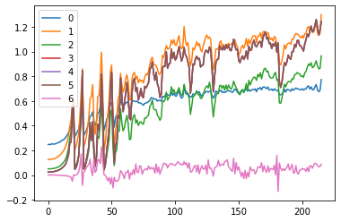

```python
for l in model.act_means: plt.plot(l)
plt.legend(range(len(model.act_means)))
```

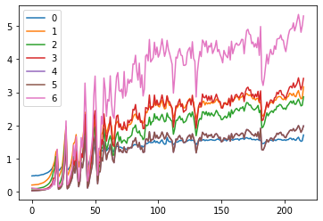

```python
for l in model.act_stds: plt.plot(l)
plt.legend(range(len(model.act_stds)))
```

```python
model.act_means[0][:10]
```

```
[tensor(0.2470, device='cuda:0'),
 tensor(0.2486, device='cuda:0'),
 tensor(0.2474, device='cuda:0'),
 tensor(0.2539, device='cuda:0'),
 tensor(0.2501, device='cuda:0'),
 tensor(0.2510, device='cuda:0'),
 tensor(0.2543, device='cuda:0'),
 tensor(0.2584, device='cuda:0'),
 tensor(0.2643, device='cuda:0'),
 tensor(0.2652, device='cuda:0')]
```

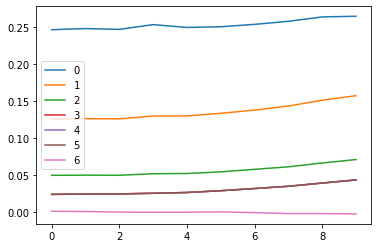

```python
for l in model.act_means: plt.plot(l[:10])
plt.legend(range(len(model.act_means)))
```

```python
model.act_stds[0][:10]
```

```
[tensor(0.4740, device='cuda:0'),
 tensor(0.4788, device='cuda:0'),
 tensor(0.4765, device='cuda:0'),
 tensor(0.4893, device='cuda:0'),
 tensor(0.4822, device='cuda:0'),
 tensor(0.4842, device='cuda:0'),
 tensor(0.4939, device='cuda:0'),
 tensor(0.5020, device='cuda:0'),
 tensor(0.5134, device='cuda:0'),
 tensor(0.5172, device='cuda:0')]
```

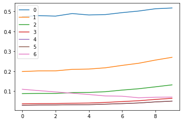

```python
for l in model.act_stds: plt.plot(l[:10])
plt.legend(range(len(model.act_stds)))
```

## Pytorch Hooks

A hook is basically a function that is executed when either forward or backward is called.

### Tensor Hooks

Normally we make some tensors with `require_grad` do some type of operation with them, like the forward pass through a network layer, and then call `.backward` to calculate the gradients so we can adjust the weights and repeat.

When that process completes we can see what gradients in the `grad` attribute but we're kind of blind as to what is happening during the calculation:

```python
a = torch.ones(5) # make a tensor
a.requires_grad = True

b = 2*a # do some operation with it
b.retain_grad()

c = b.mean() # calculate some type of final output
c.backward() # find the gradients of the output w.r.t the inputs

print(f'a: {a}', f'b: {b}', f'c: {c}',  sep='\n')
print(f'a grad: {a.grad}', f'b grad: {b.grad}', sep='\n')
```

```
a: tensor([1., 1., 1., 1., 1.], requires_grad=True)
b: tensor([2., 2., 2., 2., 2.], grad_fn=<MulBackward0>)
c: 2.0
a grad: tensor([0.4000, 0.4000, 0.4000, 0.4000, 0.4000])
b grad: tensor([0.2000, 0.2000, 0.2000, 0.2000, 0.2000])
```

This time registering a hook on `b` so we get some feedback - telemetry - on the process:

```python
a = torch.ones(5)
a.requires_grad = True

b = 2*a
b.retain_grad()

b.register_hook(lambda x: print(x))
c = b.mean()
```

```python
c.backward()
```

```
tensor([0.2000, 0.2000, 0.2000, 0.2000, 0.2000])
```

Here we can see the hook in action. After the hook is registered on `b` it prints when backward is called.

```python
print(f'a: {a}', f'b: {b}', f'c: {c}',  sep='\n')
print(f'a grad: {a.grad}', f'b grad: {b.grad}', sep='\n')
```

```
a: tensor([1., 1., 1., 1., 1.], requires_grad=True)
b: tensor([2., 2., 2., 2., 2.], grad_fn=<MulBackward0>)
c: 2.0
a grad: tensor([0.4000, 0.4000, 0.4000, 0.4000, 0.4000])
b grad: tensor([0.2000, 0.2000, 0.2000, 0.2000, 0.2000])
```

### Module Hooks

```python
class myNet(nn.Module):
    def __init__(self):
        super().__init__()
        self.conv = nn.Conv2d(3,10,2, stride = 2)
        self.relu = nn.ReLU()
        self.flatten = lambda x: x.view(-1)
        self.fc1 = nn.Linear(160,5)

    def forward(self, x):
        x = self.relu(self.conv(x))
        return self.fc1(self.flatten(x))
```

```python
def hook_fn(m, i, o):
    print(f'Module: {m}')

    print('-'*10, "Input Grad", '-'*10)

    for grad in i:
        try:
            print(grad.shape)
        except AttributeError:
            print ("None found for Gradient")

    print('-'*10, "Output Grad", '-'*10)

    for grad in o:
        try:
            print(grad.shape)
        except AttributeError:
            print ("None found for Gradient")

    print("\n")
```

```python
net = myNet()

net.conv.register_backward_hook(hook_fn)
net.fc1.register_backward_hook(hook_fn)
```

```
<torch.utils.hooks.RemovableHandle at 0x23886947040>
```

```python
inp = torch.randn(1,3,8,8)
out = net(inp)
```

Now when we call `.backward` our hook should go into action:

```python
(1 - out.mean()).backward()
```

```
Module: Linear(in_features=160, out_features=5, bias=True)
---------- Input Grad ----------
torch.Size([5])
torch.Size([5])
---------- Output Grad ----------
torch.Size([5])


Module: Conv2d(3, 10, kernel_size=(2, 2), stride=(2, 2))
---------- Input Grad ----------
None found for Gradient
torch.Size([10, 3, 2, 2])
torch.Size([10])
---------- Output Grad ----------
torch.Size([1, 10, 4, 4])
```

We can see the backward pass traveling through these two Modules.

### Forward pass Hooks on CNN model

Alright now we are ready to use hooks to capture the means and stds of our forward pass activations like we did manually above.

```python
model = get_cnn_model(data, nfs)
learn, run = get_runner(model, data, cbs=cbfs)
```

```python
act_means = [[] for _ in model]
act_stds = [[] for _ in model]
```

The hook is a function that takes three args: module, input and output as we saw above.

```python
def append_stats(i, mod, inp, out):
    act_means[i].append(out.data.mean())
    act_stds[i].append(out.data.std())
```

```python
for i, m in enumerate(model): m.register_forward_hook(partial(append_stats, i))
```

```python
run.fit(1, learn)
```

```
train: [2.29120125, tensor(0.1509, device='cuda:0')]
valid: [2.300952734375, tensor(0.1090, device='cuda:0')]
```

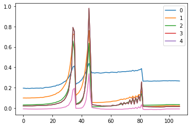

```python
for o in act_means: plt.plot(o)
plt.legend(range(5));
```

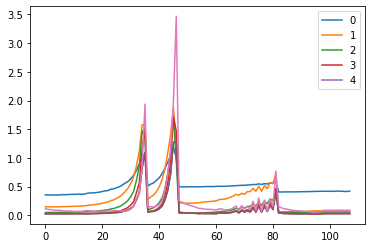

```python
for o in act_stds: plt.plot(o)
plt.legend(range(5));
```

It appears that layer `4` reacts to the other layers.

### Hook Class

`model.children()`

```
Returns an iterator over immediate children modules
```

```python
c = list(model.children());c
```

```
[Sequential(
   (0): Conv2d(1, 8, kernel_size=(5, 5), stride=(2, 2), padding=(2, 2))
   (1): ReLU()
 ),
 Sequential(
   (0): Conv2d(8, 16, kernel_size=(3, 3), stride=(2, 2), padding=(1, 1))
   (1): ReLU()
 ),
 Sequential(
   (0): Conv2d(16, 32, kernel_size=(3, 3), stride=(2, 2), padding=(1, 1))
   (1): ReLU()
 ),
 Sequential(
   (0): Conv2d(32, 32, kernel_size=(3, 3), stride=(2, 2), padding=(1, 1))
   (1): ReLU()
 ),
 AdaptiveAvgPool2d(output_size=1),
 Lambda(),
 Linear(in_features=32, out_features=10, bias=True)]
```

```python
for i in c: print(type(i))
```

```
<class 'torch.nn.modules.container.Sequential'>
<class 'torch.nn.modules.container.Sequential'>
<class 'torch.nn.modules.container.Sequential'>
<class 'torch.nn.modules.container.Sequential'>
<class 'torch.nn.modules.pooling.AdaptiveAvgPool2d'>
<class '__main__.Lambda'>
<class 'torch.nn.modules.linear.Linear'>
```

`model.modules()` recursively goes into each module in the model.

The model is essentially a tree structure.

```python
c = list(model.modules()); c
```

```
[Sequential(
   (0): Sequential(
     (0): Conv2d(1, 8, kernel_size=(5, 5), stride=(2, 2), padding=(2, 2))
     (1): ReLU()
   )
   (1): Sequential(
     (0): Conv2d(8, 16, kernel_size=(3, 3), stride=(2, 2), padding=(1, 1))
     (1): ReLU()
   )
   (2): Sequential(
     (0): Conv2d(16, 32, kernel_size=(3, 3), stride=(2, 2), padding=(1, 1))
     (1): ReLU()
   )
   (3): Sequential(
     (0): Conv2d(32, 32, kernel_size=(3, 3), stride=(2, 2), padding=(1, 1))
     (1): ReLU()
   )
   (4): AdaptiveAvgPool2d(output_size=1)
   (5): Lambda()
   (6): Linear(in_features=32, out_features=10, bias=True)
 ),
 Sequential(
   (0): Conv2d(1, 8, kernel_size=(5, 5), stride=(2, 2), padding=(2, 2))
   (1): ReLU()
 ),
 Conv2d(1, 8, kernel_size=(5, 5), stride=(2, 2), padding=(2, 2)),
 ReLU(),
 Sequential(
   (0): Conv2d(8, 16, kernel_size=(3, 3), stride=(2, 2), padding=(1, 1))
   (1): ReLU()
 ),
 Conv2d(8, 16, kernel_size=(3, 3), stride=(2, 2), padding=(1, 1)),
 ReLU(),
 Sequential(
   (0): Conv2d(16, 32, kernel_size=(3, 3), stride=(2, 2), padding=(1, 1))
   (1): ReLU()
 ),
 Conv2d(16, 32, kernel_size=(3, 3), stride=(2, 2), padding=(1, 1)),
 ReLU(),
 Sequential(
   (0): Conv2d(32, 32, kernel_size=(3, 3), stride=(2, 2), padding=(1, 1))
   (1): ReLU()
 ),
 Conv2d(32, 32, kernel_size=(3, 3), stride=(2, 2), padding=(1, 1)),
 ReLU(),
 AdaptiveAvgPool2d(output_size=1),
 Lambda(),
 Linear(in_features=32, out_features=10, bias=True)]
```

```python
for i in c: print(type(i))
```

```
<class 'torch.nn.modules.container.Sequential'>
<class 'torch.nn.modules.container.Sequential'>
<class 'torch.nn.modules.conv.Conv2d'>
<class 'torch.nn.modules.activation.ReLU'>
<class 'torch.nn.modules.container.Sequential'>
<class 'torch.nn.modules.conv.Conv2d'>
<class 'torch.nn.modules.activation.ReLU'>
<class 'torch.nn.modules.container.Sequential'>
<class 'torch.nn.modules.conv.Conv2d'>
<class 'torch.nn.modules.activation.ReLU'>
<class 'torch.nn.modules.container.Sequential'>
<class 'torch.nn.modules.conv.Conv2d'>
<class 'torch.nn.modules.activation.ReLU'>
<class 'torch.nn.modules.pooling.AdaptiveAvgPool2d'>
<class '__main__.Lambda'>
<class 'torch.nn.modules.linear.Linear'>
```

```python
#export
def children(m): return list(m.children())
```

```python
#export
class Hook():
    def __init__(self, m, f):
        self.hook = m.register_forward_hook(partial(f, self))

    def remove(self):
        self.hook.remove()

    def __del__(self):
        self.remove()
```

```python
#export
def append_stats(hook, mod, inp, outp):
    if not hasattr(hook, 'stats'): hook.stats = ([],[])
    means, std = hook.stats
    means.append(outp.data.mean())
    std.append(outp.data.std())
```

```python
model = get_cnn_model(data, nfs)
learn,run = get_runner(model, data, lr=0.5, cbs=cbfs)
```

`model.children()` vs `model.modules()`

```python
hooks = [Hook(l, append_stats) for l in children(model[:4])]
```

```python
run.fit(1, learn)
```

```
train: [2.0102946875, tensor(0.2850, device='cuda:0')]
valid: [0.89397587890625, tensor(0.6771, device='cuda:0')]
```

```python
hooks[0].stats[0][:4]
```

```
[tensor(0.1573, device='cuda:0'),
 tensor(0.1575, device='cuda:0'),
 tensor(0.1571, device='cuda:0'),
 tensor(0.1589, device='cuda:0')]
```

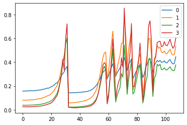

```python
for h in hooks:
    plt.plot(h.stats[0])
    h.remove()
plt.legend(range(4))
```

### Hooks Class v2 - container

#### ListContainer

We're going to write a helpful `ListContainer` class that will make it easier to store and access objects inside.

```python
#export
class ListContainer():
    def __init__(self, items):
        self.items = listify(items) #turns items into a list

    def __getitem__(self, idx):
        if isinstance(idx, (int, slice)): # if int or slice
            return self.items[idx]
        if isinstance(idx[0], bool): # if bool mask
            assert len(idx) == len(self) # check len
            return [o for m,o in zip(idx, self.items) if m] # zip and return `True` items
        return [self.items[i] for i in idx] # else if list return idx numbers

    def __len__(self):
        return len(self.items)

    def __iter__(self):
        return iter(self.items)

    def __setitem__(self, i, o): # Defines behavior for when an item is assigned to, using the notation self[nkey] = value
        self.items[i] = o

    def __delitem__(self, i):
        del(self.items[i])

    def __repr__(self):
        res = f'{self.__class__.__name__} has ({len(self)} items)\n {self.items[:10]}'
        if len(self)>10: res = res[:-1] + '...]'
        return res
```

If it has 10 items then it prints out the items...

```python
ListContainer(range(10))
```

```
ListContainer has (10 items)
 [0, 1, 2, 3, 4, 5, 6, 7, 8, 9]
```

But if there are more than 10 we get '...'

```python
ListContainer(range(100))
```

```
ListContainer has (100 items)
 [0, 1, 2, 3, 4, 5, 6, 7, 8, 9...]
```

It can also take integer indexing and Boolean masking:

```python
t = ListContainer(range(10))
t[[1,2]]
```

```
[1, 2]
```

```python
t[[False]*8 + [True,False]]
```

```
[8]
```

With this `ListContainer` we can make a new `Hooks` class.

`__enter__(self)`

```
Defines what the context manager should do at the beginning of the block created by the with statement. Note that the return value of __enter__ is bound to the target of the with statement, or the name after the as.
```

`_exit__(self, exception_type, exception_value, traceback)`

```
Defines what the context manager should do after its block has been executed (or terminates). It can be used to handle exceptions, perform cleanup, or do something always done immediately after the action in the block. If the block executes successfully, exception_type, exception_value, and traceback will be None. Otherwise, you can choose to handle the exception or let the user handle it; if you want to handle it, make sure __exit__ returns True after all is said and done. If you don't want the exception to be handled by the context manager, just let it happen.
```

```python
#export

class Hooks(ListContainer):

    def __init__(self, ms, f):
        super().__init__([Hook(m,f) for m in ms]) # stores hooks away inside ListContainer

    def __enter__(self, *args):
        return self

    def __exit__(self, *args):
        self.remove()

    def __del__(self):
        self.remove()

    def __delitem__(self, i):
        self[i].remove()
        super().__delitem__(i)

    def remove(self):
        for h in self: h.remove()
```

```python
model = get_cnn_model(data, nfs).cuda()
learn,run = get_runner(model, data, lr=0.9, cbs=cbfs)
```

```python
hooks = Hooks(model, append_stats)
```

```python
hooks
```

```
Hooks has (7 items)
 [<__main__.Hook object at 0x0000023889F6F9A0>, <__main__.Hook object at 0x0000023889F6FD90>, <__main__.Hook object at 0x0000023889EF7550>, <__main__.Hook object at 0x0000023889EF7880>, <__main__.Hook object at 0x0000023889EF75B0>, <__main__.Hook object at 0x0000023889EF7520>, <__main__.Hook object …
```

```python
hooks.remove()
```

Let's pull a batch of training data and put it through the first layer of our model:

```python
x, y = next(iter(data.train_dl))
x = mnist_resize(x).cuda()
x.mean(), x.std()
```

```
(tensor(-0.0111, device='cuda:0'), tensor(0.9883, device='cuda:0'))
```

And mean is nearly zero and the std is about 1. Great.

Now let's go ahead and put it through our first layer...

```python
p = model[0](x)
p.mean(), p.std()
```

```
(tensor(0.2343, device='cuda:0', grad_fn=<MeanBackward0>),
 tensor(0.2451, device='cuda:0', grad_fn=<StdBackward0>))
```

Something is wrong. Our mean jumps up and our std drops.

Let's initialize our model parameters:

```python
for l in model:
    if isinstance(l, nn.Sequential):
        print('Initialized', l[0].weight.shape)
        init.kaiming_normal_(l[0].weight)
        l[0].bias.data.zero_()
```

```
Initialized torch.Size([8, 1, 5, 5])
Initialized torch.Size([16, 8, 3, 3])
Initialized torch.Size([32, 16, 3, 3])
Initialized torch.Size([32, 32, 3, 3])
```

```python
p = model[0](x)
p.mean(), p.std()
```

```
(tensor(0.3508, device='cuda:0', grad_fn=<MeanBackward0>),
 tensor(0.5872, device='cuda:0', grad_fn=<StdBackward0>))
```

Better. But our mean is still too high.

Having given an `__enter__` and `__exit__` method to our `Hooks` class, we can use it as a context manager. This makes sure that onces we are out of the `with` block, all the hooks have been removed and aren't there to pollute our memory.

This is a chunky piece of code... I'll need some time with it.

```
train: [1.634779375, tensor(0.4503, device='cuda:0')]
valid: [0.436536376953125, tensor(0.8542, device='cuda:0')]
train: [0.3496819140625, tensor(0.8960, device='cuda:0')]
valid: [0.470227783203125, tensor(0.8492, device='cuda:0')]
```

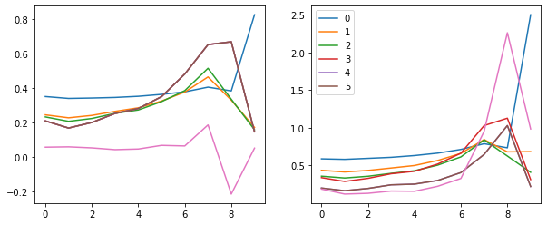

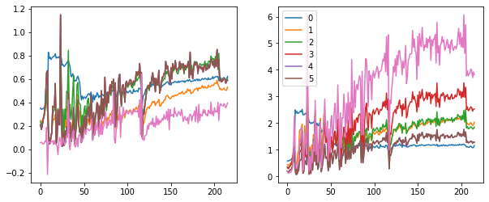

```python
with Hooks(model, append_stats) as hooks: # open context manager
    run.fit(2, learn) # train for 2 epochs

    fig, (ax0, ax1) = plt.subplots(1, 2, figsize=(10,4)) # makes 2 plots

    for h in hooks:
        ms, ss = h.stats
        ax0.plot(ms[:10])
        ax1.plot(ss[:10])
    plt.legend(range(6))

    fig,(ax0,ax1) = plt.subplots(1,2, figsize=(10,4))
    for h in hooks:
        ms, ss = h.stats
        ax0.plot(ms)
        ax1.plot(ss)
    plt.legend(range(6))
```

These plots give us an idea of where our mean and standard deviation are throughout the training process for each layer.

### Other Statistics

Now let's try to visualize our activations in addition to the means and standard deviations for each layer.

Again we will need to write the hook function which we'll register with each layer by using our context manager `Hook` class:

```python
def append_stats(hook, mod, inp, outp):
    if not hasattr(hook, 'stats'): hook.stats = ([],[],[])
    means, stds, hists = hook.stats
    means.append(outp.data.mean().cpu())
    stds.append(outp.data.std().cpu())
    hists.append(outp.data.cpu().histc(40, 0, 10))
```

Now let's get our model and initialize the weights:

```python
model = get_cnn_model(data, nfs)
learn, run = get_runner(model, data, cbs=cbfs)
```

```python
for l in model:
    if isinstance(l, nn.Sequential):
        print('Initialized', l[0].weight.shape)
        print(l[0])
        init.kaiming_normal_(l[0].weight)
        l[0].bias.data.zero_()
```

```
Initialized torch.Size([8, 1, 5, 5])
Conv2d(1, 8, kernel_size=(5, 5), stride=(2, 2), padding=(2, 2))
Initialized torch.Size([16, 8, 3, 3])
Conv2d(8, 16, kernel_size=(3, 3), stride=(2, 2), padding=(1, 1))
Initialized torch.Size([32, 16, 3, 3])
Conv2d(16, 32, kernel_size=(3, 3), stride=(2, 2), padding=(1, 1))
Initialized torch.Size([32, 32, 3, 3])
Conv2d(32, 32, kernel_size=(3, 3), stride=(2, 2), padding=(1, 1))
```

```python
with Hooks(model, append_stats) as hooks: run.fit(1, learn)
```

```
train: [1.063923984375, tensor(0.6577, device='cuda:0')]
valid: [0.20301553955078125, tensor(0.9421, device='cuda:0')]
```

Let's take a closer look at how this is all put together and what our stats look like.

`hooks` is an instance of our `Hooks` class which inherits from the `ListContainer` class - descriptive naming.

```python
isinstance(hooks, Hooks)
```

```
True
```

The `hooks` object contains 7 items. Each one corresponds to a layer of the network and is an instance of the `Hook` class which actually does the registering for that layer.

```python
hooks
```

```
Hooks has (7 items)
 [<__main__.Hook object at 0x0000023889F74580>, <__main__.Hook object at 0x0000023889F74A30>, <__main__.Hook object at 0x0000023889FCCD90>, <__main__.Hook object at 0x0000023889FCCC10>, <__main__.Hook object at 0x0000023889FCCD00>, <__main__.Hook object at 0x0000023889F7FB50>, <__main__.Hook object …
```

```python
isinstance(hooks[0], Hook)
```

```
True
```

Then the `append_stats` functions creates a `stats` attribute in each one of the `hooks`.

We do a calculation for a stat after every batch. So we would expect the number of stats collected would equal the number of batches in an epoch (assuming 1 training epoch consisting of training and validation)

```python
len(hooks[0].stats[0]) == len(data.train_dl) + len(data.valid_dl)
```

```
True
```

Great. Now we can index into it to pull out the saved stats that were calculated when the model was training.

```python
# means layer 0
hooks[0].stats[0][:5]
```

```
[tensor(0.4198),
 tensor(0.3971),
 tensor(0.4087),
 tensor(0.4151),
 tensor(0.4346)]
```

```python
# means layer 1
hooks[1].stats[0][:5]
```

```
[tensor(0.3757),
 tensor(0.3285),
 tensor(0.3508),
 tensor(0.3670),
 tensor(0.4109)]
```

```python
# stds layer 0
hooks[0].stats[1][:5]
```

```
[tensor(0.8021),
 tensor(0.7365),
 tensor(0.7591),
 tensor(0.7789),
 tensor(0.8302)]
```

```python
# stds layer 1
hooks[1].stats[1][:5]
```

```
[tensor(0.8642),
 tensor(0.7051),
 tensor(0.7555),
 tensor(0.8271),
 tensor(0.9610)]
```

For the activations we can see for each layer the shape of the tensor is 108 x 40: 108 being the number of batches and 40 being the number of bins we specified in the `append_stats` function.

```python
# activations layer 0
torch.stack(hooks[0].stats[2]).shape
```

```
torch.Size([108, 40])
```

#### Plotting Hook Stats as histograms:

Pytorch provides a method to automatically bin tensors for histograms

```python
a = torch.stack(hooks[3].stats[2])[0];a
```

```
tensor([4.4853e+04, 6.2820e+03, 4.3820e+03, 2.8850e+03, 2.0110e+03, 1.4340e+03,
        9.5200e+02, 6.9700e+02, 5.4900e+02, 4.1700e+02, 3.1000e+02, 2.1800e+02,
        1.6000e+02, 1.0300e+02, 8.1000e+01, 5.8000e+01, 4.0000e+01, 2.5000e+01,
        2.8000e+01, 2.3000e+01, 9.0000e+00, 5.0000e+00, 0.0000e+00, 5.0000e+00,
        4.0000e+00, 2.0000e+00, 2.0000e+00, 0.0000e+00, 0.0000e+00, 1.0000e+00,
        0.0000e+00, 0.0000e+00, 0.0000e+00, 0.0000e+00, 0.0000e+00, 0.0000e+00,
        0.0000e+00, 0.0000e+00, 0.0000e+00, 0.0000e+00])
```

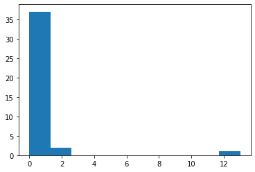

```python
plt.hist(a.histc(bins=40, min=0, max=10))
```

### Activation Histograms

- https://forums.fast.ai/t/the-colorful-dimension/42908/5
- https://forums.fast.ai/t/the-twin-peaks-chart/49065

```python
def get_hist(h):
    return torch.stack(h.stats[2]).t().float().log1p()
```

```python
mpl.rcParams['image.cmap'] = 'viridis'
```

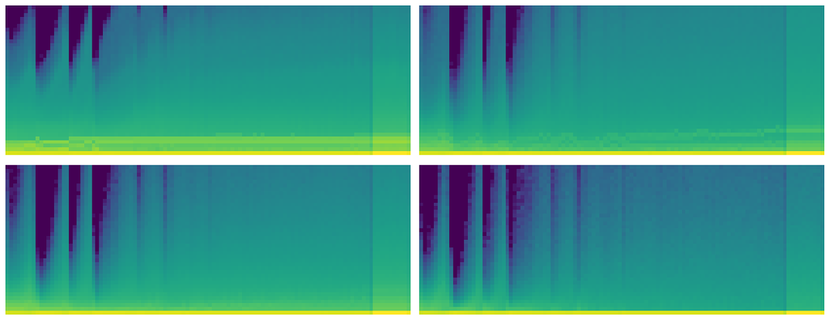

```python
fig, axes = plt.subplots(2,2, figsize=(15,6))
for ax, h in zip(axes.flatten(), hooks[:4]):
    ax.imshow(get_hist(h), origin='lower')
    ax.axis('off')
plt.tight_layout()
```

Another useful measurement would be to find the minimum

```python
def get_min(h):
    h1 = torch.stack(h.stats[2]).t().float()
    return h1[:2].sum(0)/h1.sum(0)
```

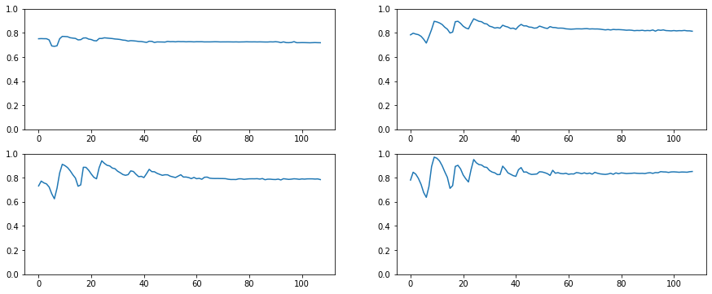

```python
fig, axes = plt.subplots(2,2, figsize=(15,6))

for ax,h in zip(axes.flatten(), hooks[:4]):
    ax.plot(get_min(h))
    ax.set_ylim(0,1)
```

### Generalized ReLU

[figure not shown]

We'd like to be able to use a generalize ReLU function that takes parameters.

Let's start by refactoring our `get_cnn_layers` function. Instead of the `conv2d` function to get a conv and RelU we will replace it will a function we'll pass as an arg.

```python
#export
def get_cnn_layers(data, nfs, layer, **kwargs):
    nfs = [1] + nfs
    return [layer(nfs[i], nfs[i+1], 5 if i==0 else 3, **kwargs) for i in range(len(nfs)-1)] + [
        nn.AdaptiveAvgPool2d(1), Lambda(flatten), nn.Linear(nfs[-1], data.c)]
```

Next we'll define that `layer` function.

The main difference between this and the original `conv2d` function we've been using is that this replaces the `nn.RelU` module with a `GeneralRelu` class instance which we'll define below.

```python
#export
def conv_layer(ni, nf, ks=3, stride=2, **kwargs):
    return nn.Sequential(
    nn.Conv2d(ni, nf, kernel_size=ks, padding=ks//2, stride=stride), GeneralRelu(**kwargs))
```

The `GeneralRelu` class just inherits from the `nn.Module` class and we define the forward pass based on the passed `args`:

If `leak` then use `F.leaky_relu`, if `sub` then just subtract a given value, and if `maxv` then `clamp_max` the tensor.

```python
#export
class GeneralRelu(nn.Module):
    def __init__(self, leak=None, sub=None, maxv=None):
        super().__init__()
        self.leak, self.sub, self.maxv = leak, sub, maxv

    def forward(self, x):
        x = F.leaky_relu(x, self.leak) if self.leak is not None else F.relu(x)
        if self.sub is not None: x.sub_(self.sub)
        if self.maxv is not None: x.clamp_max_(self.maxv)
        return x
```

And let's make a conv weight initializer:

```python
#export
def init_cnn(m, uniform=False):
    initzer = init.kaiming_normal_ if not uniform else init.kaiming_uniform_
    for l in m:
        if isinstance(l, nn.Sequential):
            print('Layer Initialized', l[0].weight.shape)
            initzer(l[0].weight, a=0.1) # why a=0.1
            l[0].bias.data.zero_()
```

Lastly, let's alter our `get_cnn_model` so that we can pass parameters to our new generalized Relu

```python
#export
def get_cnn_model(data, nfs, layer, **kwargs):
    return nn.Sequential(*get_cnn_layers(data, nfs, layer, **kwargs))
```

Our `append_stats` function above was clamping the activation histograms between 0 and 10. We need to change that now to allow for our leaky relu:

```python
def append_stats(hook, mod, inp, outp):
    if not hasattr(hook, 'stats'): hook.stats = ([],[],[])
    means, stds, hists = hook.stats
    means.append(outp.data.mean().cpu())
    stds.append(outp.data.std().cpu())
    hists.append(outp.data.cpu().histc(40, -7, 10))
```

Let's once again plot our means and stds for the layers and see where we are with our new leaky relu:

```python
model = get_cnn_model(data, nfs, conv_layer, leak=0.1, sub=0.4, maxv=6.)
init_cnn(model)
learn, run = get_runner(model, data, lr=0.9, cbs=cbfs)
```

```
Layer Initialized torch.Size([8, 1, 5, 5])
Layer Initialized torch.Size([16, 8, 3, 3])
Layer Initialized torch.Size([32, 16, 3, 3])
Layer Initialized torch.Size([32, 32, 3, 3])
```

```
train: [0.5131076953125, tensor(0.8406, device='cuda:0')]
valid: [0.143439501953125, tensor(0.9586, device='cuda:0')]
```

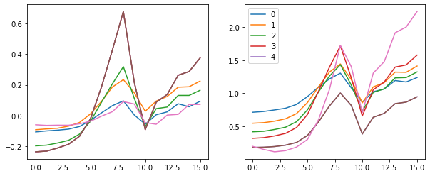

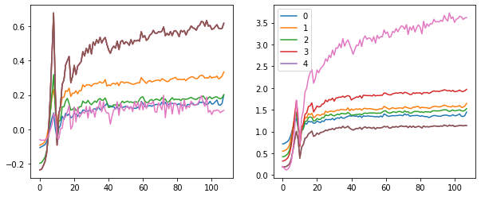

```python
with Hooks(model, append_stats) as hooks:
    run.fit(1, learn)
    fig, (ax0, ax1) = plt.subplots(1,2, figsize=(10,4))

    for h in hooks:
        ms, ss, hi = h.stats
        ax0.plot(ms[:16])
        ax1.plot(ss[:16])
        h.remove()
    plt.legend(range(5))

    fig, (ax0, ax1) = plt.subplots(1,2, figsize=(10,4))

    for h in hooks:
        ms, ss, hi = h.stats
        ax0.plot(ms)
        ax1.plot(ss)
        h.remove()
    plt.legend(range(5))
```

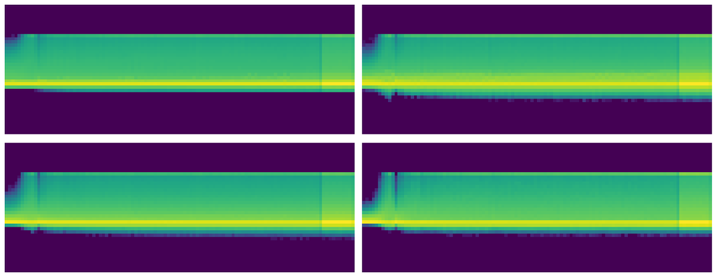

```python
fig,axes = plt.subplots(2,2, figsize=(15,6))
for ax,h in zip(axes.flatten(), hooks[:4]):
    ax.imshow(get_hist(h), origin='lower')
    ax.axis('off')
plt.tight_layout()
```

Again let's look at the minimum:

```python
# 19:22 ????
def get_min(h):
    h1 = torch.stack(h.stats[2]).t().float()
    return h1[19:22].sum(0)/h1.sum(0)
```

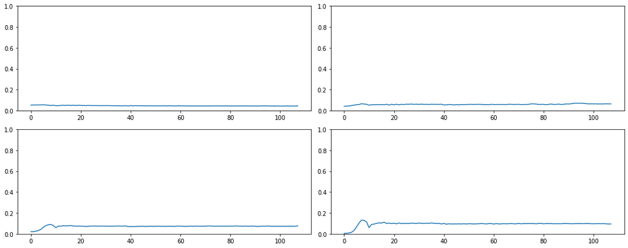

```python
fig, axes = plt.subplots(2,2, figsize=(15, 6))
for ax, h in zip(axes.flatten(), hooks[:4]):
    ax.plot(get_min(h))
    ax.set_ylim(0,1)
plt.tight_layout()
```

Let's make it easier to get our `learn` and `run`:

```python
#export
def get_learn_run(data, nfs, layer, lr, cbs=None, opt_func=None, uniform=False, **kwargs):
    model = get_cnn_model(data, nfs, layer, **kwargs)
    init_cnn(model, uniform=uniform)
    return get_runner(model, data, lr=lr, cbs=cbs, opt_func=opt_func)
```

```python
sched = combine_scheds([0.5, 0.5], [sched_cos(0.2, 1.), sched_cos(1., 0.1)])
```

```python
learn, run = get_learn_run(data, nfs, conv_layer, lr=0.3, cbs=cbfs+[partial(ParamScheduler, 'lr', sched)])
```

```
Layer Initialized torch.Size([8, 1, 5, 5])
Layer Initialized torch.Size([16, 8, 3, 3])
Layer Initialized torch.Size([32, 16, 3, 3])
Layer Initialized torch.Size([32, 32, 3, 3])
```

```python
run.fit(8, learn)
```

```
train: [1.08220671875, tensor(0.6515, device='cuda:0')]
valid: [0.33779599609375, tensor(0.8951, device='cuda:0')]
train: [0.4042448046875, tensor(0.8813, device='cuda:0')]
valid: [0.1759971435546875, tensor(0.9495, device='cuda:0')]
train: [0.26224583984375, tensor(0.9219, device='cuda:0')]
valid: [0.138768994140625, tensor(0.9588, device='cuda:0')]
train: [0.2970945703125, tensor(0.9112, device='cuda:0')]
valid: [0.1135945556640625, tensor(0.9676, device='cuda:0')]
train: [0.09405572265625, tensor(0.9716, device='cuda:0')]
valid: [0.120890087890625, tensor(0.9631, device='cuda:0')]
train: [0.064376962890625, tensor(0.9801, device='cuda:0')]
valid: [0.06530327758789063, tensor(0.9800, device='cuda:0')]
train: [0.0466950732421875, tensor(0.9861, device='cuda:0')]
valid: [0.06019769287109375, tensor(0.9825, device='cuda:0')]
train: [0.0386482568359375, tensor(0.9887, device='cuda:0')]
valid: [0.058825421142578126, tensor(0.9827, device='cuda:0')]
```

```python
learn,run = get_learn_run(data, nfs,conv_layer, lr=.5, uniform=True,
                          cbs=cbfs+[partial(ParamScheduler,'lr', sched)])
```

```
Layer Initialized torch.Size([8, 1, 5, 5])
Layer Initialized torch.Size([16, 8, 3, 3])
Layer Initialized torch.Size([32, 16, 3, 3])
Layer Initialized torch.Size([32, 32, 3, 3])
```

```python
run.fit(8, learn)
```

```
train: [0.9983809375, tensor(0.6972, device='cuda:0')]
valid: [0.3271009521484375, tensor(0.9141, device='cuda:0')]
train: [0.367025390625, tensor(0.8945, device='cuda:0')]
valid: [0.2927641845703125, tensor(0.9111, device='cuda:0')]
train: [0.2038186328125, tensor(0.9394, device='cuda:0')]
valid: [0.11736240234375, tensor(0.9667, device='cuda:0')]
train: [0.28083064453125, tensor(0.9168, device='cuda:0')]
valid: [0.1443911865234375, tensor(0.9567, device='cuda:0')]
train: [0.092182265625, tensor(0.9723, device='cuda:0')]
valid: [0.08942604370117188, tensor(0.9747, device='cuda:0')]
train: [0.06406564453125, tensor(0.9805, device='cuda:0')]
valid: [0.07181917114257813, tensor(0.9795, device='cuda:0')]
train: [0.04830845703125, tensor(0.9846, device='cuda:0')]
valid: [0.06663142700195313, tensor(0.9801, device='cuda:0')]
train: [0.039549384765625, tensor(0.9886, device='cuda:0')]
valid: [0.064864306640625, tensor(0.9806, device='cuda:0')]
```

```python
#export
from IPython.display import display, Javascript
def nb_auto_export():
    display(Javascript("""{
const ip = IPython.notebook
if (ip) {
    ip.save_notebook()
    console.log('a')
    const s = `!python notebook2script.py ${ip.notebook_name}`
    if (ip.kernel) { ip.kernel.execute(s) }
}
}"""))
```

```python
nb_auto_export()
```